# Arbeidskrav 2 uke 43- Inference

Emilie S. Larsen

## Innledning:

I Haun et al. (2019) sin studie forsket de på muskelfibertype og bestemmelse av fibertype sammensettnighos tidligere trente unge menn. I studien deltok 30 unge menn i 6 ukers styrketrening med høyt volum. De ble delt inn i to grupper HIGH og LOW bestemt av hypertrofi-score, av prøver som ble tatt før intervensjonen. I denne oppgaven skal vi se på endring av testosteron nivå i begge gruppene. Tidligere studier har funnet sammenheng med langsiktig muskelhypertrofi og økte mengder med testosteron (Fink, Schoenfeld, and Nakazato 2018). I studen til Magine et al. (Mangine et al. 2017) viste deres største funn at den endokrine responsen på styrketrening og spesielt testosteron er relatert til muskelhypertrofi over 8 ukers trening. Noe som tidligere bare var en sterk korrelasjon i andre studier.

### Hypotese:

Vi forventer at HIGH gruppen får en større økning i testosteron enn det LOW gruppen vil få. Stor nok vil si at jeg setter pverdien til 0.005.

```
## # A tibble: 2 x 2
##   CLUSTER testosterone.m
##   <fct>            <dbl>
## 1 LOW             -19.8
## 2 HIGH              6.92
```

## Konklusjon:

Vi konkludere med at det ikke er noe forksjell i testo verdiene i HIGH gruppen i forhold til LOW gruppen fra T1 til T3 (mean difference, -26.8, 95% CI [-103.8, 50.3]; t(15.9) = -0.74, p = 0.472)

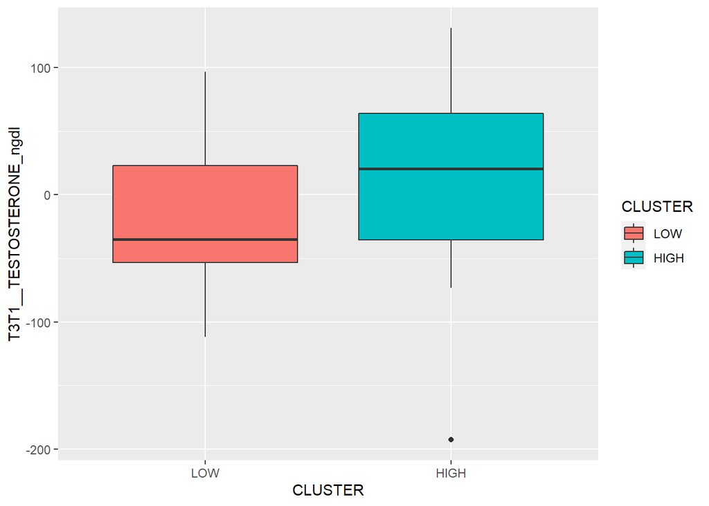

### Referanser:

Fink, J., B. J. Schoenfeld, and K. Nakazato. 2018. “The role of hormones in muscle hypertrophy.” *Phys Sportsmed* 46 (1): 129–34.

Haun, C. T., C. G. Vann, C. B. Mobley, S. C. Osburn, P. W. Mumford, P. A. Roberson, M. A. Romero, et al. 2019. “Pre-training Skeletal Muscle Fiber Size and Predominant Fiber Type Best Predict Hypertrophic Responses to 6 Weeks of Resistance Training in Previously Trained Young Men.” *Front Physiol* 10: 297.

Mangine, G. T., J. R. Hoffman, A. M. Gonzalez, J. R. Townsend, A. J. Wells, A. R. Jajtner, K. S. Beyer, et al. 2017. “Exercise-Induced Hormone Elevations Are Related to Muscle Growth.” *J Strength Cond Res* 31 (1): 45–53.